# Project1 - Hedge Fund Return Drivers and Factors

### MaxDrawdown

#### Companies

```r
d <- make_date(year = format(index(co.ret.xts), format = '%Y'), month = format(index(co.ret.xts), format = '%m'), day = 1)
Redwood <- co.ret.xts[,1]
Renaissance <- co.ret.xts[,2]
SEG <- co.ret.xts[,3]

index(Redwood) = d
index(Renaissance) = d
index(SEG) = d
```

```
##         From     Trough         To   Depth Length To Trough Recovery
## 1 2007-01-01 2009-02-01 2016-11-01 -0.6533    119        26       93
## 2 2018-07-01 2020-03-01 2020-11-01 -0.4102     29        21        8
## 3 1998-05-01 1998-08-01 2000-09-01 -0.2077     29         4       25
## 4 2022-03-01 2022-10-01       <NA> -0.1708      9         8       NA
## 5 2004-04-01 2004-04-01 2004-09-01 -0.0673      6         1        5
```

```
##         From     Trough         To   Depth Length To Trough Recovery
## 1 2007-06-01 2009-04-01 2011-06-01 -0.3567     49        23       26
## 2 2020-02-01 2021-01-01       <NA> -0.2759     34        12       NA
## 3 2013-05-01 2013-08-01 2013-10-01 -0.0668      6         4        2
## 4 2015-02-01 2015-06-01 2015-07-01 -0.0528      6         5        1
## 5 2013-12-01 2014-01-01 2014-03-01 -0.0522      4         2        2
```

```
##         From     Trough         To   Depth Length To Trough Recovery
## 1 2008-06-01 2009-02-01       <NA> -0.2998     30         9       NA
## 2 1999-07-01 1999-11-01 2000-05-01 -0.1796     11         5        6
## 3 2000-06-01 2000-09-01 2000-11-01 -0.1119      6         4        2
## 4 2007-11-01 2008-02-01 2008-05-01 -0.0794      7         4        3
## 5 2001-07-01 2001-09-01 2002-01-01 -0.0687      7         3        4
```

```
##                 Redwood Renaissance       SEG
## Worst Drawdown 0.653272   0.3566567 0.2997651
```

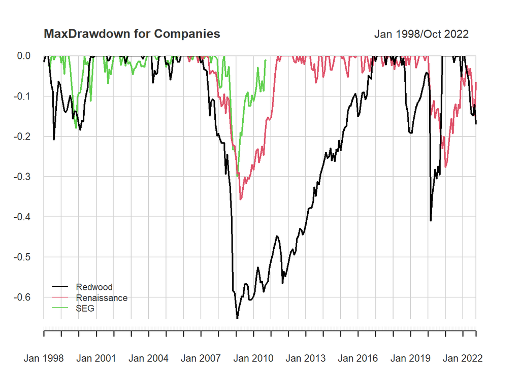

#### Indices

```r
d <- make_date(year = format(index(index.xts), format = '%Y'), month = format(index(index.xts), format = '%m'), day = 1)
Value <- index.xts[,1]
Momentum <- index.xts[,2]
Carry <- index.xts[,3]
Defensive <- index.xts[,4]
Multi.Style <- index.xts[,5]
Market <- index.xts[,6]

index(Value) = d
index(Momentum) = d
index(Carry) = d
index(Defensive) = d
index(Multi.Style) = d
index(Market) = d
```

```
##         From     Trough         To   Depth Length To Trough Recovery
## 1 2005-02-01 2021-12-01       <NA> -0.3995    213       203       NA
## 2 1999-05-01 2000-04-01 2001-12-01 -0.2122     32        12       20
## 3 1998-03-01 1998-07-01 1998-10-01 -0.1707      8         5        3
## 4 2002-11-01 2003-02-01 2003-07-01 -0.0488      9         4        5
## 5 1998-01-01 1998-01-01 1998-02-01 -0.0468      2         1        1
```

```
##         From     Trough         To   Depth Length To Trough Recovery
## 1 2000-03-01 2003-08-01 2008-11-01 -0.3101    105        42       63
## 2 1998-08-01 1999-04-01 1999-12-01 -0.1664     17         9        8
## 3 2020-10-01 2021-04-01       <NA> -0.1518     25         7       NA
## 4 2012-06-01 2013-06-01 2015-07-01 -0.1386     38        13       25
## 5 2015-12-01 2019-04-01 2020-05-01 -0.1356     54        41       13
```

```
##         From     Trough         To   Depth Length To Trough Recovery
## 1 2013-06-01 2022-07-01       <NA> -0.5003    113       110       NA
## 2 2007-04-01 2009-07-01 2011-02-01 -0.1596     47        28       19
## 3 2000-02-01 2001-05-01 2007-03-01 -0.1540     86        16       70
## 4 1998-03-01 1998-08-01 1999-05-01 -0.1374     15         6        9
## 5 1999-06-01 1999-07-01 2000-01-01 -0.0921      8         2        6
```

```
##         From     Trough         To   Depth Length To Trough Recovery
## 1 1998-02-01 2000-02-01 2006-01-01 -0.3715     96        25       71
## 2 2020-11-01 2022-01-01       <NA> -0.1468     24        15       NA
## 3 2008-12-01 2010-07-01 2013-02-01 -0.1434     51        20       31
## 4 2016-08-01 2017-05-01 2018-08-01 -0.1079     25        10       15
## 5 2007-11-01 2008-07-01 2008-10-01 -0.0969     12         9        3
```

```
##         From     Trough         To   Depth Length To Trough Recovery
## 1 2014-03-01 2022-01-01       <NA> -0.1505    104        95       NA
## 2 2002-10-01 2002-11-01 2003-12-01 -0.0820     15         2       13
## 3 1998-05-01 2001-05-01 2001-08-01 -0.0580     40        37        3
## 4 2008-12-01 2009-05-01 2011-02-01 -0.0524     27         6       21
## 5 2001-09-01 2001-12-01 2002-07-01 -0.0485     11         4        7
```

```
##         From     Trough         To   Depth Length To Trough Recovery
## 1 2007-11-01 2009-02-01 2014-05-01 -0.5545     79        16       63
## 2 2000-09-01 2003-03-01 2006-02-01 -0.4963     66        31       35
## 3 2020-01-01 2020-03-01 2020-11-01 -0.2036     11         3        8
## 4 1998-08-01 1998-09-01 1999-04-01 -0.2002      9         2        7
## 5 2022-01-01 2022-09-01       <NA> -0.1535     10         9       NA
```

```
##                    Value  Momentum    Carry Defensive Multi-Style    Market
## Worst Drawdown 0.3995358 0.3100549 0.500267 0.3715036   0.1504647 0.5544956
```

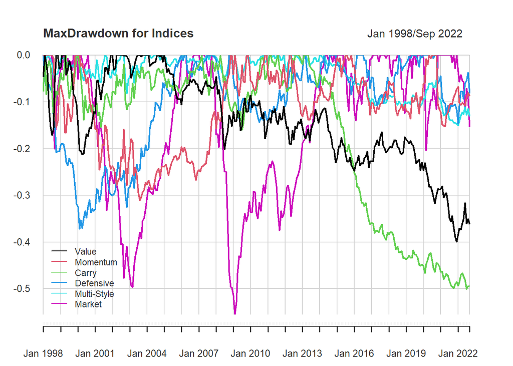

### Observation

#### For Companies

1. Redwood is much volatile compared to Renaissance and SEG. The Volatility plot validate this conclusion.
2. Based on the fundamental investment theory, the higher the volatility, the higher the returns we can anticipate. So Redwood should provide better returns to compensate its high volatility. However, based on the culmulative return analysis, we observe that it has underperformed by both SEG and Renaissance from 1998 and 2007 respectively. Currently the return of Renaissance is the double of Redwood.
3. Beside returns, we delve into more metrics. The overall Sharpe ratio of Redwood is the lowest among the three, while SEG is the highest. However, it doesn’t account for the COVID effect on the market. If we only observe the period for both SEG and Renaissance operate, we can find the Sharpe ratio of these two companies are quite similar.
4. If we observe Sharpe ratio by rolling basis, we can know that Redwood is extremely unstable with highest 6-7% and lowest -6% per month. Renaissance and SEG are mostly bounded between +2% and -2% per month.
5. As for max drawdown, three companies suffered severely from 2008 financial crisis. The worst drawdown for the three all happened in this period. If we look at the COVID pandemic, we can find that the drawdown for Renaissance is not a lot less severe compared to the financial crisis, while the drawdown for Redwood is less severe compared to the financial crisis.
6. Another observation is that during the COVID period, Redwood’s performance bounced back quicker than Renaissance’s, showing its instability.

#### For Indices

1. Market is the most volatile one, followed by the Momentum.
2. Based on the cumulative return analysis, the rank is Market > Momentum > Defensive > Multi-Style > Value > Carry, which aligns with the investment theory that the higher the volatility, the higher the return we can expect. The reason behind is that for the previous few years, the stock market soared a lot, which was beneficial for both Market and Momentum.
3. Another implication from the cumulative return is that we can validate the three Hedge Funds indeed beat the indices.
4. As for Sharpe ratio, Market is the most volatile, but is not quite different from others in most years. Another interesting thing I observed is that the Value and Market seem to have counter effect as their performance showed quite opposite to each other.
5. As for max drawdown, different indices show quite different patterns.
- Value starts the downward trend after 2008 financial crisis.
- Momentum shows oscillatory pattern because of the core idea of the momentum strategy.
- Carry slumped a lot from 2015 and has not yet bounced back.
- Defensive also shows oscillatory throughout past few years.
- Multi-Style is relatively stable as it incorporates various kinds of companies to reduce its risks.
- Market is greatly influenced by the market condition. Whenever there is a big trouble in the market, it suffers the most.

## Regression

### Redwood

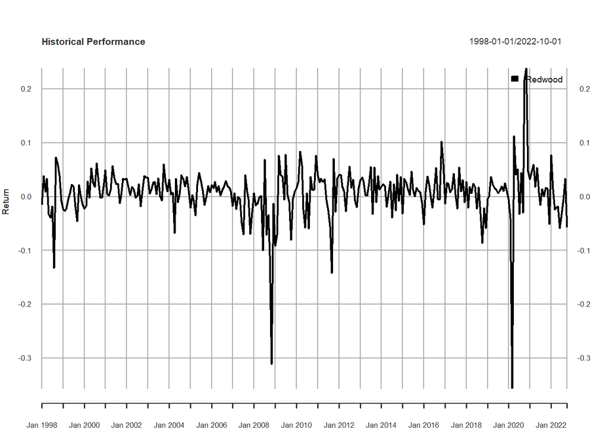

```r
Redwood_reg <- Redwood[2:length(Redwood),]
index.reg.xts <- index.xts
index(index.reg.xts) <- as.yearmon(index(Redwood_reg))
Redwood_reg <- cbind(Redwood_reg, index.reg.xts)
```

### Pairwise Evaluation

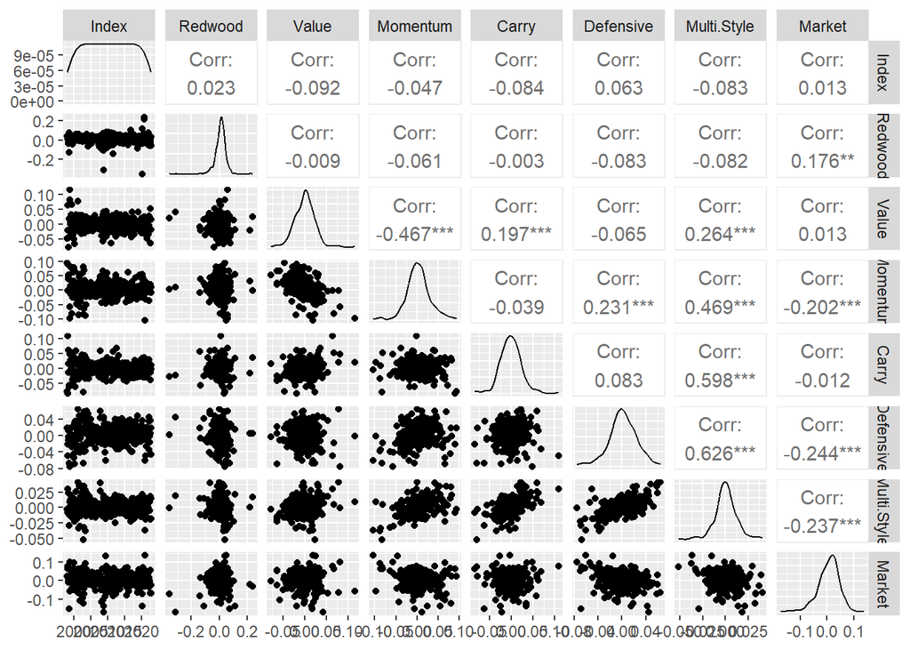

```
##             Redwood  Value Momentum  Carry Defensive Multi.Style Market
## Redwood       1.000 -0.009   -0.061 -0.003    -0.083      -0.082  0.176
## Value        -0.009  1.000   -0.467  0.197    -0.065       0.264  0.013
## Momentum     -0.061 -0.467    1.000 -0.039     0.231       0.469 -0.202
## Carry        -0.003  0.197   -0.039  1.000     0.083       0.598 -0.012
## Defensive    -0.083 -0.065    0.231  0.083     1.000       0.626 -0.244
## Multi.Style  -0.082  0.264    0.469  0.598     0.626       1.000 -0.237
## Market        0.176  0.013   -0.202 -0.012    -0.244      -0.237  1.000
```

```r
ggpairs(Redwood_reg)
```

### Regression Model

```r
lm_redwood_v1 = lm(Redwood ~ ., data = Redwood_reg)
summary(lm_redwood_v1)
```

```
##
## Call:
## lm(formula = Redwood ~ ., data = Redwood_reg)
##
## Residuals:
##      Min       1Q   Median       3Q      Max
## -0.34691 -0.01849  0.00345  0.02121  0.23465
##
## Coefficients:
##               Estimate Std. Error t value Pr(>|t|)
## (Intercept)  6.416e-03  2.841e-03   2.258  0.02468 *
## Value        3.123e+05  3.338e+05   0.935  0.35037
## Momentum     3.123e+05  3.338e+05   0.935  0.35037
## Carry        3.123e+05  3.338e+05   0.935  0.35037
## Defensive    3.123e+05  3.338e+05   0.935  0.35037
## Multi.Style -1.249e+06  1.335e+06  -0.935  0.35037
## Market       1.847e-01  6.792e-02   2.719  0.00694 **
## ---
## Signif. codes:  0 '***' 0.001 '**' 0.01 '*' 0.05 '.' 0.1 ' ' 1
##
## Residual standard error: 0.04808 on 290 degrees of freedom
## Multiple R-squared:  0.03683,    Adjusted R-squared:  0.01691
## F-statistic: 1.848 on 6 and 290 DF,  p-value: 0.08968
```

```r
anova(lm_redwood_v1)
```

```
## Analysis of Variance Table
##
## Response: Redwood
##              Df  Sum Sq   Mean Sq F value   Pr(>F)
## Value         1 0.00006 0.0000601  0.0260 0.872069
## Momentum      1 0.00380 0.0037973  1.6426 0.200996
## Carry         1 0.00001 0.0000072  0.0031 0.955423
## Defensive     1 0.00337 0.0033740  1.4595 0.227997
## Multi.Style   1 0.00131 0.0013091  0.5663 0.452350
## Market        1 0.01709 0.0170909  7.3930 0.006943 **
## Residuals   290 0.67041 0.0023118
## ---
## Signif. codes:  0 '***' 0.001 '**' 0.01 '*' 0.05 '.' 0.1 ' ' 1
```

```r
coefficients(lm_redwood_v1) # model coefficients
```

```
##   (Intercept)         Value      Momentum         Carry     Defensive
##  6.415607e-03  3.122769e+05  3.122769e+05  3.122770e+05  3.122769e+05
##   Multi.Style        Market
## -1.249108e+06  1.846720e-01
```

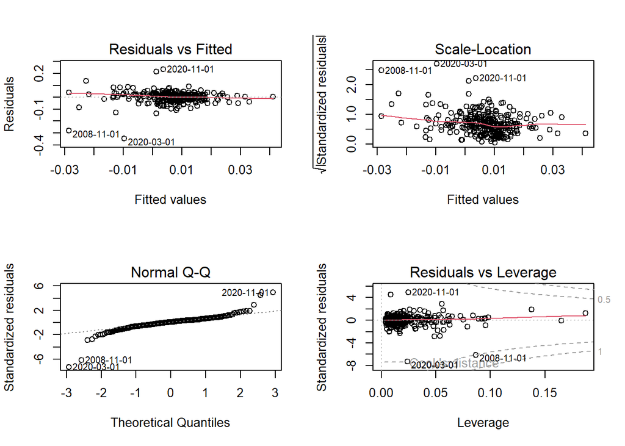

### Backward Selection

Use backward selection to iteratively remove predictors for the purpose of finding the subset of variables in the data set resulting in the best performing model and reducing the prediction error.

```
## Start:  AIC=-1795.8
## Redwood ~ Value + Momentum + Carry + Defensive + Multi.Style +
##     Market
##
##               Df Sum of Sq     RSS     AIC
## - Defensive    1 0.0020227 0.67244 -1796.9
## - Value        1 0.0020227 0.67244 -1796.9
## - Momentum     1 0.0020227 0.67244 -1796.9
## - Multi.Style  1 0.0020227 0.67244 -1796.9
## - Carry        1 0.0020227 0.67244 -1796.9
## <none>                     0.67041 -1795.8
## - Market       1 0.0170909 0.68751 -1790.3
##
## Step:  AIC=-1796.9
## Redwood ~ Value + Momentum + Carry + Multi.Style + Market
##
##               Df Sum of Sq     RSS     AIC
## - Value        1 0.0000178 0.67246 -1798.9
## - Momentum     1 0.0000431 0.67248 -1798.9
## - Carry        1 0.0006264 0.67306 -1798.6
## - Multi.Style  1 0.0009444 0.67338 -1798.5
## <none>                     0.67244 -1796.9
## + Defensive    1 0.0020227 0.67041 -1795.8
## - Market       1 0.0163773 0.68881 -1791.8
##
## Step:  AIC=-1798.89
## Redwood ~ Momentum + Carry + Multi.Style + Market
##
##               Df Sum of Sq     RSS     AIC
## - Momentum     1 0.0000265 0.67248 -1800.9
## - Carry        1 0.0006545 0.67311 -1800.6
## - Multi.Style  1 0.0014459 0.67390 -1800.3
## <none>                     0.67246 -1798.9
## + Value        1 0.0000178 0.67244 -1796.9
## + Defensive    1 0.0000178 0.67244 -1796.9
## - Market       1 0.0165463 0.68900 -1793.7
##
## Step:  AIC=-1800.88
## Redwood ~ Carry + Multi.Style + Market
##
```

[output cut: 17 more lines]

```
## + Momentum     1 0.0000476 0.67311 -1800.6
## + Value        1 0.0000000 0.67316 -1800.6
## - Market       1 0.0181606 0.69132 -1796.7
##
## Step:  AIC=-1804.05
## Redwood ~ Market
##
##               Df Sum of Sq     RSS     AIC
## <none>                     0.67437 -1804.0
## + Multi.Style  1 0.0012144 0.67316 -1802.6
## + Defensive    1 0.0011978 0.67317 -1802.6
## + Momentum     1 0.0004677 0.67390 -1802.2
## + Value        1 0.0000941 0.67428 -1802.1
## + Carry        1 0.0000006 0.67437 -1802.0
## - Market       1 0.0216815 0.69605 -1796.7
```

```
##
## Call:
## lm(formula = Redwood ~ Market, data = Redwood_reg)
##
## Residuals:
##      Min       1Q   Median       3Q      Max
## -0.34833 -0.01826  0.00360  0.02040  0.23817
##
## Coefficients:
##             Estimate Std. Error t value Pr(>|t|)
## (Intercept) 0.006086   0.002790   2.181  0.02995 *
## Market      0.198107   0.064327   3.080  0.00227 **
## ---
## Signif. codes:  0 '***' 0.001 '**' 0.01 '*' 0.05 '.' 0.1 ' ' 1
##
## Residual standard error: 0.04781 on 295 degrees of freedom
## Multiple R-squared:  0.03115,    Adjusted R-squared:  0.02786
## F-statistic: 9.484 on 1 and 295 DF,  p-value: 0.002267
```

```
## Analysis of Variance Table
##
## Response: Redwood
##            Df  Sum Sq  Mean Sq F value   Pr(>F)
## Market      1 0.02168 0.021681  9.4844 0.002267 **
## Residuals 295 0.67437 0.002286
## ---
## Signif. codes:  0 '***' 0.001 '**' 0.01 '*' 0.05 '.' 0.1 ' ' 1
```

Model: Redwood Return(m) = 0.006 + 0.198 * Equity_Indices_Market(m-1)

From the pairwise evaluation we can find that the correlation between Redwood’s returns and all the variables is small. Only the Market is a little bit related to it (but only 0.176). As a result, the backward selection gives a result of simple linear model which only contains Market as the variable.

The reasons behind it may be the investment focus of Redwood. It mainly invests in financial, industrial, and consumer discretionary sector. All these three are quite easily affected by the market condition.

### Renaissance

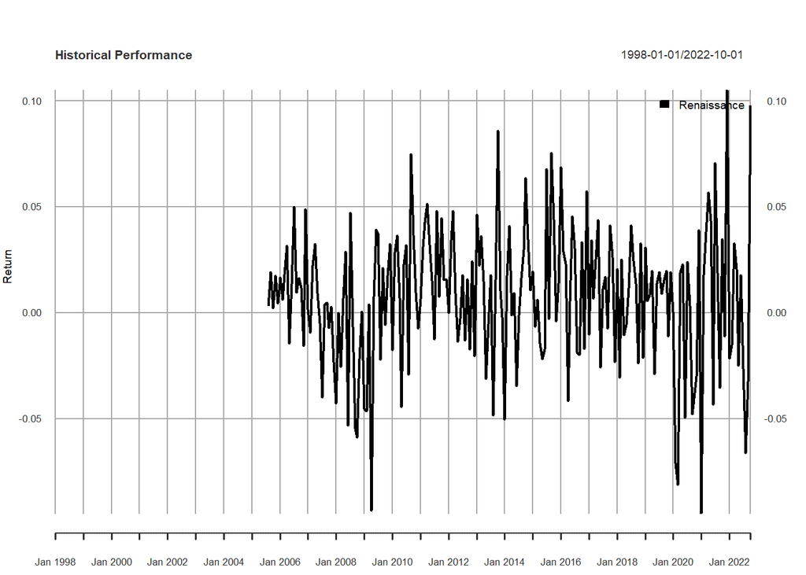

```r
Renaissance_reg <- Renaissance[2:length(Renaissance),]
Renaissance_reg <- cbind(Renaissance, index.reg.xts)
Renaissance_reg <- na.omit(Renaissance_reg)
```

### Pairwise Evaluation

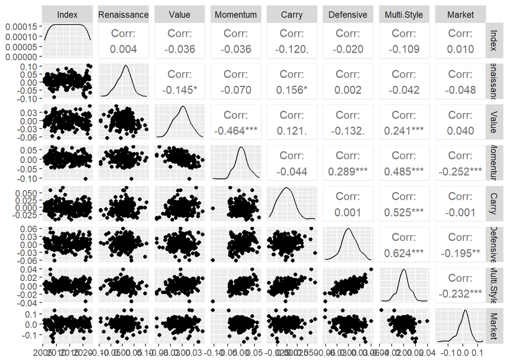

```
##             Renaissance  Value Momentum  Carry Defensive Multi.Style Market
## Renaissance       1.000 -0.145   -0.070  0.156     0.002      -0.042 -0.048
## Value            -0.145  1.000   -0.464  0.121    -0.132       0.241  0.040
## Momentum         -0.070 -0.464    1.000 -0.044     0.289       0.485 -0.252
## Carry             0.156  0.121   -0.044  1.000     0.001       0.525 -0.001
## Defensive         0.002 -0.132    0.289  0.001     1.000       0.624 -0.195
## Multi.Style      -0.042  0.241    0.485  0.525     0.624       1.000 -0.232
## Market           -0.048  0.040   -0.252 -0.001    -0.195      -0.232  1.000
```

```r
ggpairs(Renaissance_reg)
```

### Regression Model

```r
lm_renaissance_v1 = lm(Renaissance ~ ., data = Renaissance_reg)
summary(lm_renaissance_v1)
```

```
##
## Call:
## lm(formula = Renaissance ~ ., data = Renaissance_reg)
##
## Residuals:
##       Min        1Q    Median        3Q       Max
## -0.103613 -0.021133  0.003351  0.019217  0.092661
##
## Coefficients:
##               Estimate Std. Error t value Pr(>|t|)
## (Intercept)  8.155e-03  2.271e-03   3.591 0.000415 ***
## Value       -2.737e+05  3.446e+05  -0.794 0.428069
## Momentum    -2.737e+05  3.446e+05  -0.794 0.428069
## Carry       -2.737e+05  3.446e+05  -0.794 0.428070
## Defensive   -2.737e+05  3.446e+05  -0.794 0.428070
## Multi.Style  1.095e+06  1.379e+06   0.794 0.428070
## Market      -6.910e-02  5.594e-02  -1.235 0.218166
## ---
## Signif. codes:  0 '***' 0.001 '**' 0.01 '*' 0.05 '.' 0.1 ' ' 1
##
## Residual standard error: 0.03179 on 200 degrees of freedom
## Multiple R-squared:  0.08663,    Adjusted R-squared:  0.05922
## F-statistic: 3.161 on 6 and 200 DF,  p-value: 0.005522
```

```r
anova(lm_renaissance_v1)
```

```
## Analysis of Variance Table
##
## Response: Renaissance
##              Df   Sum Sq   Mean Sq F value   Pr(>F)
## Value         1 0.004640 0.0046396  4.5907 0.033354 *
## Momentum      1 0.005310 0.0053098  5.2538 0.022940 *
## Carry         1 0.006921 0.0069207  6.8478 0.009553 **
## Defensive     1 0.000098 0.0000985  0.0974 0.755254
## Multi.Style   1 0.000659 0.0006594  0.6525 0.420195
## Market        1 0.001542 0.0015422  1.5260 0.218166
## Residuals   200 0.202130 0.0010106
## ---
## Signif. codes:  0 '***' 0.001 '**' 0.01 '*' 0.05 '.' 0.1 ' ' 1
```

```r
coefficients(lm_renaissance_v1) # model coefficients
```

```
##   (Intercept)         Value      Momentum         Carry     Defensive
##  8.154580e-03 -2.736757e+05 -2.736756e+05 -2.736750e+05 -2.736753e+05
##   Multi.Style        Market
##  1.094701e+06 -6.910225e-02
```

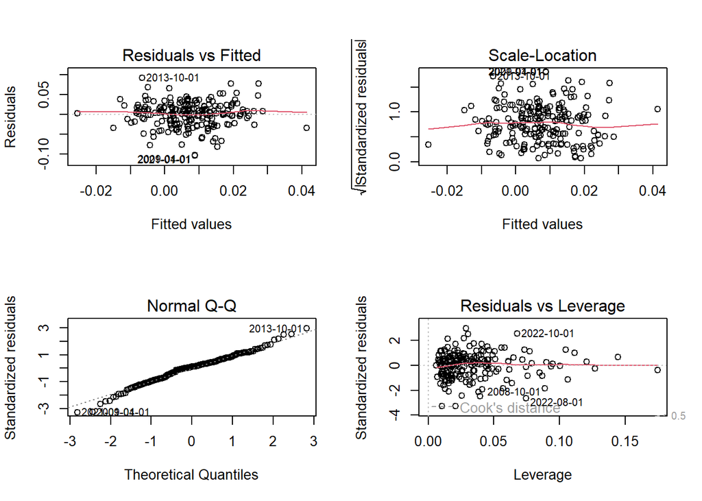

### Backward Selection

Use backward selection to iteratively remove predictors for the purpose of finding the subset of variables in the data set resulting in the best performing model and reducing the prediction error.

```
## Start:  AIC=-1420.83
## Renaissance ~ Value + Momentum + Carry + Defensive + Multi.Style +
##     Market
##
##               Df  Sum of Sq     RSS     AIC
## - Carry        1 0.00063733 0.20277 -1422.2
## - Defensive    1 0.00063733 0.20277 -1422.2
## - Multi.Style  1 0.00063733 0.20277 -1422.2
## - Momentum     1 0.00063734 0.20277 -1422.2
## - Value        1 0.00063734 0.20277 -1422.2
## - Market       1 0.00154223 0.20367 -1421.3
## <none>                      0.20213 -1420.8
##
## Step:  AIC=-1422.18
## Renaissance ~ Value + Momentum + Defensive + Multi.Style + Market
##
##               Df Sum of Sq     RSS     AIC
## - Market       1 0.0015643 0.20433 -1422.6
## <none>                     0.20277 -1422.2
## - Defensive    1 0.0030978 0.20586 -1421.0
## + Carry        1 0.0006373 0.20213 -1420.8
## - Multi.Style  1 0.0068945 0.20966 -1417.3
## - Momentum     1 0.0133420 0.21611 -1411.0
## - Value        1 0.0161458 0.21891 -1408.3
##
## Step:  AIC=-1422.59
## Renaissance ~ Value + Momentum + Defensive + Multi.Style
##
##               Df Sum of Sq     RSS     AIC
## <none>                     0.20433 -1422.6
## + Market       1 0.0015643 0.20277 -1422.2
## - Defensive    1 0.0027295 0.20706 -1421.8
## + Carry        1 0.0006594 0.20367 -1421.3
## - Multi.Style  1 0.0068954 0.21123 -1417.7
## - Momentum     1 0.0122541 0.21659 -1412.5
## - Value        1 0.0155946 0.21993 -1409.4
```

```
##
## Call:
## lm(formula = Renaissance ~ Value + Momentum + Defensive + Multi.Style,
##     data = Renaissance_reg)
##
## Residuals:
##       Min        1Q    Median        3Q       Max
## -0.104428 -0.018720  0.002805  0.017512  0.088633
##
## Coefficients:
##              Estimate Std. Error t value Pr(>|t|)
## (Intercept)  0.007673   0.002244   3.419 0.000760 ***
## Value       -0.697078   0.177536  -3.926 0.000118 ***
## Momentum    -0.559998   0.160893  -3.481 0.000613 ***
## Defensive   -0.269504   0.164065  -1.643 0.102007
## Multi.Style  1.219725   0.467170   2.611 0.009708 **
## ---
## Signif. codes:  0 '***' 0.001 '**' 0.01 '*' 0.05 '.' 0.1 ' ' 1
##
## Residual standard error: 0.0318 on 202 degrees of freedom
## Multiple R-squared:  0.07668,    Adjusted R-squared:  0.05839
## F-statistic: 4.194 on 4 and 202 DF,  p-value: 0.00277
```

```
## Analysis of Variance Table
##
## Response: Renaissance
##              Df   Sum Sq   Mean Sq F value   Pr(>F)
## Value         1 0.004640 0.0046396  4.5867 0.033419 *
## Momentum      1 0.005310 0.0053098  5.2492 0.022989 *
## Defensive     1 0.000124 0.0001238  0.1224 0.726795
## Multi.Style   1 0.006895 0.0068954  6.8167 0.009708 **
## Residuals   202 0.204332 0.0010115
## ---
## Signif. codes:  0 '***' 0.001 '**' 0.01 '*' 0.05 '.' 0.1 ' ' 1
```

Model: Renaissance(m) = 0.008 - 0.697 Equity_Indices_Value(m-1) - 0.56 Equity_Indices_Momentum(m-1) - 0.27 Equity_Indices_Defensive(m-1) + 1.22 Equity_Indices_Multi-Style(m-1)

The investment objective is to provide long-term capital growth through capital appreciation by investing primarily in a diversified portfolio of equity securities of foreign companies located in Europe, the Far East and the Pacific Rim. After delving into its holdings, we can find that it incorporates healthcare, industrials, information technology, consumer discretionary, etc, and across diversified countries. That’s the reason why the coefficient of the Multi-Style is positive and obviously larger than other variables’.

### SEG

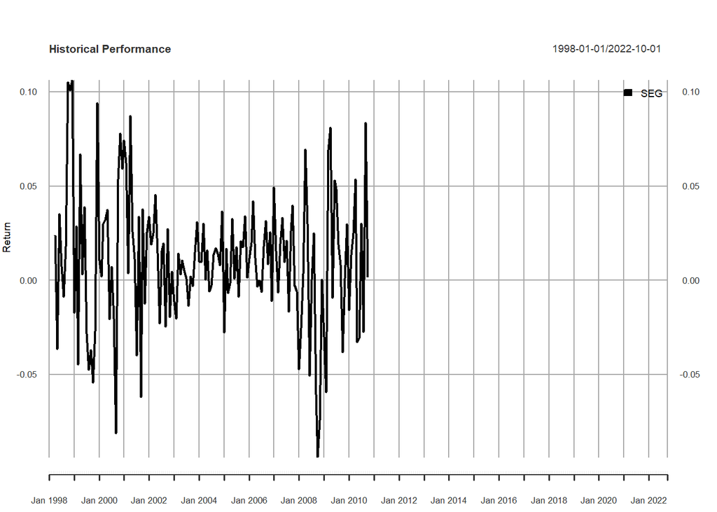

```r
SEG_reg <- SEG[2:length(SEG),]
SEG_reg <- cbind(SEG, index.reg.xts)
SEG_reg <- na.omit(SEG_reg)
```

### Pairwise Evaluation

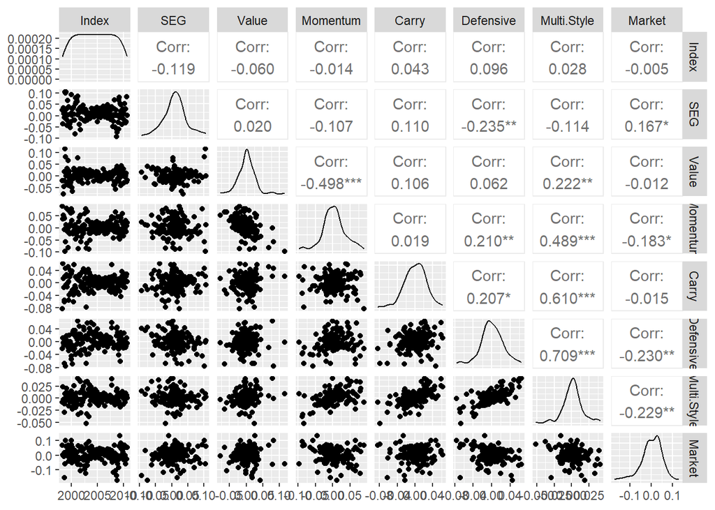

```
##                SEG  Value Momentum  Carry Defensive Multi.Style Market
## SEG          1.000  0.020   -0.107  0.110    -0.235      -0.114  0.167
## Value        0.020  1.000   -0.498  0.106     0.062       0.222 -0.012
## Momentum    -0.107 -0.498    1.000  0.019     0.210       0.489 -0.183
## Carry        0.110  0.106    0.019  1.000     0.207       0.610 -0.015
## Defensive   -0.235  0.062    0.210  0.207     1.000       0.709 -0.230
## Multi.Style -0.114  0.222    0.489  0.610     0.709       1.000 -0.229
## Market       0.167 -0.012   -0.183 -0.015    -0.230      -0.229  1.000
```

```r
ggpairs(SEG_reg)
```

### Regression Model

```r
lm_seg_v1 = lm(SEG ~ ., data = SEG_reg)
summary(lm_seg_v1)
```

```
##
## Call:
## lm(formula = SEG ~ ., data = SEG_reg)
##
## Residuals:
##       Min        1Q    Median        3Q       Max
## -0.083108 -0.018288  0.000642  0.018487  0.094258
##
## Coefficients:
##               Estimate Std. Error t value Pr(>|t|)
## (Intercept)  1.034e-02  2.874e-03   3.597 0.000441 ***
## Value        2.706e+05  3.060e+05   0.884 0.378046
## Momentum     2.706e+05  3.060e+05   0.884 0.378046
## Carry        2.706e+05  3.060e+05   0.884 0.378046
## Defensive    2.706e+05  3.060e+05   0.884 0.378047
## Multi.Style -1.082e+06  1.224e+06  -0.884 0.378046
## Market       8.500e-02  6.059e-02   1.403 0.162801
## ---
## Signif. codes:  0 '***' 0.001 '**' 0.01 '*' 0.05 '.' 0.1 ' ' 1
##
## Residual standard error: 0.03477 on 144 degrees of freedom
## Multiple R-squared:  0.1002, Adjusted R-squared:  0.0627
## F-statistic: 2.672 on 6 and 144 DF,  p-value: 0.01729
```

```r
anova(lm_seg_v1)
```

```
## Analysis of Variance Table
##
## Response: SEG
##              Df   Sum Sq   Mean Sq F value   Pr(>F)
## Value         1 0.000079 0.0000786  0.0650 0.799104
## Momentum      1 0.002426 0.0024264  2.0071 0.158724
## Carry         1 0.002694 0.0026940  2.2285 0.137675
## Defensive     1 0.011163 0.0111632  9.2342 0.002822 **
## Multi.Style   1 0.000641 0.0006414  0.5305 0.467566
## Market        1 0.002379 0.0023792  1.9681 0.162801
## Residuals   144 0.174081 0.0012089
## ---
## Signif. codes:  0 '***' 0.001 '**' 0.01 '*' 0.05 '.' 0.1 ' ' 1
```

```r
coefficients(lm_seg_v1) # model coefficients
```

```
##   (Intercept)         Value      Momentum         Carry     Defensive
##  1.033830e-02  2.706119e+05  2.706118e+05  2.706121e+05  2.706116e+05
##   Multi.Style        Market
## -1.082448e+06  8.500429e-02
```

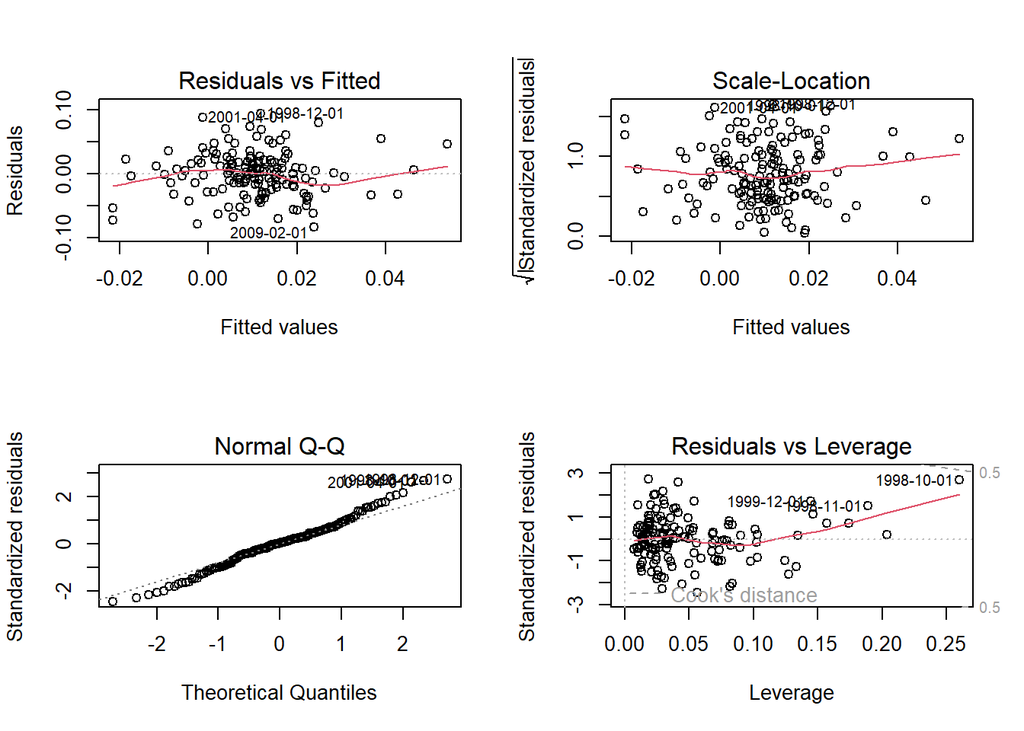

### Backward Selection

Use backward selection to iteratively remove predictors for the purpose of finding the subset of variables in the data set resulting in the best performing model and reducing the prediction error.

```
## Start:  AIC=-1007.59
## SEG ~ Value + Momentum + Carry + Defensive + Multi.Style + Market
##
##               Df  Sum of Sq     RSS     AIC
## - Defensive    1 0.00094519 0.17503 -1008.8
## - Momentum     1 0.00094519 0.17503 -1008.8
## - Value        1 0.00094519 0.17503 -1008.8
## - Multi.Style  1 0.00094519 0.17503 -1008.8
## - Carry        1 0.00094519 0.17503 -1008.8
## <none>                      0.17408 -1007.6
## - Market       1 0.00237924 0.17646 -1007.5
##
## Step:  AIC=-1008.78
## SEG ~ Value + Momentum + Carry + Multi.Style + Market
##
##               Df Sum of Sq     RSS     AIC
## - Market       1 0.0020754 0.17710 -1009.0
## <none>                     0.17503 -1008.8
## - Momentum     1 0.0032020 0.17823 -1008.0
## - Value        1 0.0034142 0.17844 -1007.9
## + Defensive    1 0.0009452 0.17408 -1007.6
## - Multi.Style  1 0.0091143 0.18414 -1003.1
## - Carry        1 0.0114152 0.18644 -1001.2
##
## Step:  AIC=-1009
## SEG ~ Value + Momentum + Carry + Multi.Style
##
##               Df Sum of Sq     RSS     AIC
## <none>                     0.17710 -1009.0
## + Market       1 0.0020754 0.17503 -1008.8
## - Momentum     1 0.0033558 0.18046 -1008.2
## - Value        1 0.0037058 0.18081 -1007.9
## + Defensive    1 0.0006414 0.17646 -1007.5
## - Multi.Style  1 0.0111632 0.18826 -1001.8
## - Carry        1 0.0131677 0.19027 -1000.2
```

```
##
## Call:
## lm(formula = SEG ~ Value + Momentum + Carry + Multi.Style, data = SEG_reg)
##
## Residuals:
##       Min        1Q    Median        3Q       Max
## -0.089499 -0.019463  0.001483  0.018841  0.098981
##
## Coefficients:
##              Estimate Std. Error t value Pr(>|t|)
## (Intercept)  0.010714   0.002868   3.736 0.000268 ***
## Value        0.334113   0.191157   1.748 0.082592 .
## Momentum     0.286344   0.172156   1.663 0.098402 .
## Carry        0.583076   0.176972   3.295 0.001236 **
## Multi.Style -1.411224   0.465197  -3.034 0.002861 **
## ---
## Signif. codes:  0 '***' 0.001 '**' 0.01 '*' 0.05 '.' 0.1 ' ' 1
##
## Residual standard error: 0.03483 on 146 degrees of freedom
## Multiple R-squared:  0.08457,    Adjusted R-squared:  0.05949
## F-statistic: 3.372 on 4 and 146 DF,  p-value: 0.01133
```

```
## Analysis of Variance Table
##
## Response: SEG
##              Df   Sum Sq   Mean Sq F value   Pr(>F)
## Value         1 0.000079 0.0000786  0.0648 0.799433
## Momentum      1 0.002426 0.0024264  2.0003 0.159400
## Carry         1 0.002694 0.0026940  2.2209 0.138312
## Multi.Style   1 0.011163 0.0111632  9.2028 0.002861 **
## Residuals   146 0.177102 0.0012130
## ---
## Signif. codes:  0 '***' 0.001 '**' 0.01 '*' 0.05 '.' 0.1 ' ' 1
```

Model: SEG(m) = 0.011 + 0.334 Equity_Indices_Value(m-1) + 0.286 Equity_Indices_Momentum(m-1) + 0.583 Equity_Indices_Carry(m-1) - 1.411 Equity_Indices_Multi-Style(m-1)

The Firm manages its assets across long-only and long/short equity strategies that invest in high-quality companies across geographies and market capitalizations. So we can know why Value can have a positive effect for predicting SEG’s return.